# Estimating and Plotting an Estimated Ump Zone

Gradon Nicholls

2024-01-20

## Packages

We rely on the following packages:

```r
pkglist = c("tidyverse","baseballr","ggthemr","ggpubr","MASS","caret","mda","Compositional","ks")
if (!require("pacman")) {
  install.packages("pacman")
}
pacman::p_load(char=pkglist)
rm(pkglist)

# avoids clash of select functions between dplyr and MASS
select <- dplyr::select
```

## Background

### Umpires and strikezones

Consider a typical at-bat during a game of Major League Baseball (MLB):

- the pitcher throws (**pitches**) the baseball towards the hitter
- the hitter may attempt to swing at the ball
- if the hitter chooses *not* to swing, the umpire **calls** the pitch either…
  - a **strike** if the ball falls within the **strikezone**
  - a **ball** if the ball falls outside the **strikezone**
- three strikes result in the hitter getting called out, while four balls result in the hitter getting to proceed to first base

The umpire’s call is thus extremely important for how a game proceeds. Furthermore, the umpire’s call is *not* reviewable. It is common for players and fans to direct anger at umpires for poor calls, particularly if they occur during a high-stakes moment.

Thanks to a plethora of available data, fans have taken it upon themselves to track ump performance. [Ump Scorecards](https://umpscorecards.com) in particular tweets a visual summary of each ump’s performance after every game. The objective of this tutorial is to show how to produce an Estimated Umpire Zone (EUZ) in R. The EUZ shows how the ump’s called balls and strikes differ from the official strike zone, and allows one to measure an ump’s internal consistency (that is, does an ump follow their own strike zone?).

To compare to the official strikezone, we need to know its dimensions:

> “The official strike zone is the **area over home plate** from the **midpoint between a batter’s shoulders and the top of the uniform pants** – when the batter is in his stance and prepared to swing at a pitched ball – and **a point just below the kneecap**.”

In other words, the strike zone *depends on the physiology of each player!* Figure 1 shows an approximate average strike zone based on Hunter (2018).

Figure 1: Approximating the Official MLB Strike Zone

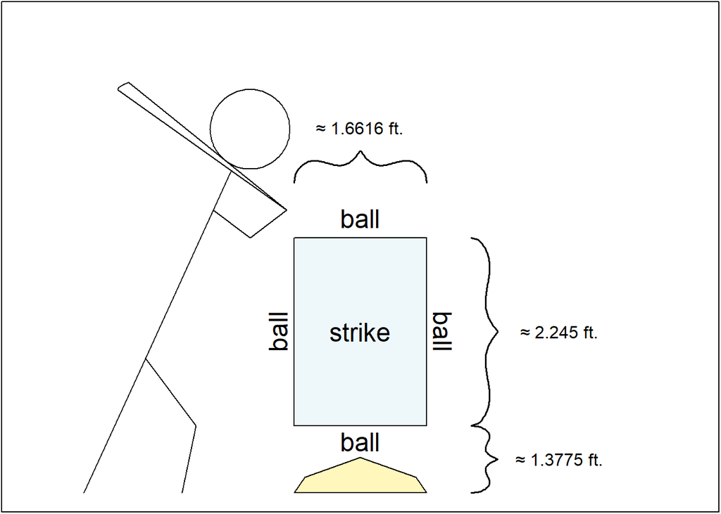

### Classification

Computing the EUZ is a classification task. Specifically, we want to model the probability a pitch is called a strike as a function of the $x$ (horizontal) and $z$ (vertical) coordinates of the point where the baseball crossed home plate. Denote this by $\Pr(\text{strike}\,\, |\,\, x,z)$. Then the EUZ is the set of $(x,z)$ coordinates defined by $\Pr(\text{strike}\,\, |\,\, x,z) > 0.5$, that is, it is the area where a pitch is more likely to be called a strike than a ball.

$$\Pr(\text{strike}\,\, |\,\, x,z) = \frac{f(x,z\,\,|\,\,\text{strike})\Pr(\text{strike})}{f(x,z\,\,|\,\,\text{strike})\Pr(\text{strike}) + f(x,z\,\,|\,\,\text{ball})\Pr(\text{ball})}$$

By using Bayes’ theorem, we decompose the problem into two parts:

- Estimate $\Pr(\text{ball})$ and $\Pr(\text{strike})$ based on the sample proportions of balls and strikes.
- Estimate the joint density functions $f(x,z\,\,|\,\,\text{strike})$ and $f(x,z\,\,|\,\,\text{ball})$.

We summarise the Bayes-theorem-based methods below, and the assumptions they make about the joint densities:

- Quadratic discriminant analysis (**QDA**): $X,Z\,\,|\,\,\text{call} \sim \text{N}(\vec{\mu}_\text{call},\Sigma_\text{call})$
- Naive Bayes (**NB**) with Kernel Density Estimation (**KDE**):
  - Assume independence: $f(x,z\,\,|\,\,\text{call}) = f_x(x\,\,|\,\,\text{call})f_z(z\,\,|\,\,\text{call})$
  - $f_x,f_z$ estimated non-parametrically using KDE
- Multivariate KDE (**MKDE**): $f(x,z\,\,|\,\,\text{call})$ estimated non-parametrically using MKDE

## Data

We rely on the `baseballr` package to collect **Statcast** pitching data from MLB. For the sake of this tutorial we look at the 2022 home opener that the Toronto Blue Jays (**TOR**) played against the Texas Rangers (**TEX**) on April 8th. Statcast provides x and z coordinates of each pitch. We restrict the analysis to the 162 called pitches made during the game, of which 116 were balls and 46 were strikes.

```r
data = statcast_search_pitchers(
  start_date = "2022-04-08",
  end_date = "2022-04-08"
)
TORgame = data %>%
  filter(home_team=="TOR") %>%
  arrange(at_bat_number,pitch_number) %>%
  filter(description=="ball" | description=="called_strike")
TORgame %>%
  select(c(plate_x,plate_z,description))
```

```
## ── MLB Baseball Savant Statcast Search data from baseballsavant.mlb.com ────────
```

```
## ℹ Data updated: 2024-01-20 15:52:30 EST
```

```
## # A tibble: 162 × 3
##    plate_x plate_z description
##      <dbl>   <dbl> <chr>
##  1   -1.63    2.57 ball
##  2    0.2     1.8  called_strike
##  3    0.21    3.81 ball
##  4   -1.17    2.98 ball
##  5   -0.98    2.45 ball
##  6    1.09    1.49 ball
##  7   -0.6     2.39 called_strike
##  8   -0.49    1.35 ball
##  9    0.94    2.46 ball
## 10   -0.32    1.1  ball
## # ℹ 152 more rows
```

Figure 2 plots these 162 pitches against the approximate official strike zone.

Figure 2: Called Pitches (TEX @ TOR April 8 2022)

[figure not shown]

```r
# theme
ggthemr("flat")

# plot
Figure2 = ggplot(data=TORgame) +
  geom_point(aes(x=plate_x,y=plate_z,color=description,shape=description),size=4) +
  scale_color_manual(name="Pitch Call", labels=c("Ball","Strike"),
                     values=c(adjustcolor("deepskyblue4",alpha.f=0.6),adjustcolor("firebrick3",alpha.f=0.6))) +
  scale_shape_manual(name="Pitch Call", labels=c("Ball","Strike"),values=c(16,16))+
  geom_rect(aes(xmin=-0.8308,xmax=0.8308,ymin=1.3775,ymax=3.6225),
            fill=NA,colour="black",linewidth=1) +
  scale_x_continuous(name="x (ft. from center)",breaks=-3:3,limits=c(-3,3)) +
  scale_y_continuous(name="z (ft. from ground)",breaks=0:6,limits=c(0,6)) +
  theme(panel.grid.minor=element_blank(),
        plot.caption = element_text(hjust = 0,size=17),
        text = element_text(size = 18),
        legend.position="bottom")

# figure notes
annotate_figure(Figure2,
  bottom=text_grob(
    "Note: The black rectangle represents the approximate rule book strike zone.\nSource: Statcast Pitch Data (Toronto vs. Texas, April 2 2022).",
    hjust=0,x=unit(0,"npc")))
```